```r
library(tidyverse)
```

```r
library(ggplot2)
library(caret)
df <- readr::read_csv("paint_project_train_data.csv", col_names = TRUE)
df_scaled <- df %>%
  mutate(y = boot::logit(response / 100)) %>%
  select(R, G, B, Hue, Saturation, Lightness,y, outcome) %>%
  mutate(outcome = ifelse(outcome == 1, 'event', 'non_event'),
         outcome = factor(outcome, levels = c('event', 'non_event')))
```

### Loading models

```r
linear_models_names <- list(
  'ENET_tune_1',
'ENET_tune_2',
'ENEET_default_1',
'ENET_default_2',
'LM_default_1',
'LM_default_2',
'LM_default_3',
'LM_default_4',
'NNET_default',
'NNET_tune',
'RF',
'XGB_default',
'XGB_tune',
'reg_svm_linear',
'reg_svm_poly',
'reg_mars'
)
```

```r
logistic_models_roc_names <- list(
  'glm_default_roc_1',
    'glm_default_roc_2',
    'glm_default_roc_3',
    'glm_default_roc_4',
    'enet_default_roc_1',
    'enet_default_roc_2',
    'enet_tune_roc_1',
    'enet_tune_roc_2',
    'nnet_default_roc',
    'nnet_tune_roc',
    'rf_default_roc',
    'xgb_default_roc',
    'xgb_tune_roc'
)
```

```r
logistic_models_acc_names <- list(
  'glm_default_acc_1',
    'glm_default_acc_2',
    'glm_default_acc_3',
    'glm_default_acc_4',
    'enet_default_acc_1',
    'enet_default_acc_2',
    'enet_tune_acc_1',
    'enet_tune_acc_2',
    'nnet_default_acc',
    'nnet_tune_acc',
    'rf_default_acc',
    'xgb_default_acc',
    'xgb_tune_acc',
    'cl_svm_linear',
  'cl_svm_poly',
  'cl_mars'
)
```

```r
load_rds_model <- function(name) {
  readr::read_rds(paste(name, '.rds', sep = ''))
}
```

```r
linear_models <- tibble::tibble(
  names = linear_models_names,
  models = names %>% purrr::map(load_rds_model)
)
```

```r
logistic_models_acc <- tibble::tibble(
  names = logistic_models_acc_names,
  models = names %>% purrr::map(load_rds_model)
)
```

```r
logistic_models_roc <- tibble::tibble(
  names = logistic_models_roc_names,
  models = names %>% purrr::map(load_rds_model)
)
```

### Choosing best models

```r
linear_resamples <- caret::resamples(setNames(linear_models$models, linear_models$names))
```

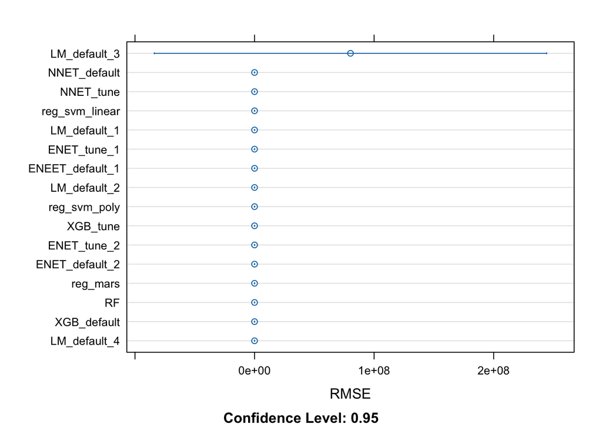

```r
linear_resamples  %>% dotplot(metric = 'RMSE')
```

Best model is `LM_default_4`.

```r
logistic_resamples_acc <- resamples(setNames(logistic_models_acc$models, logistic_models_acc$names))
```

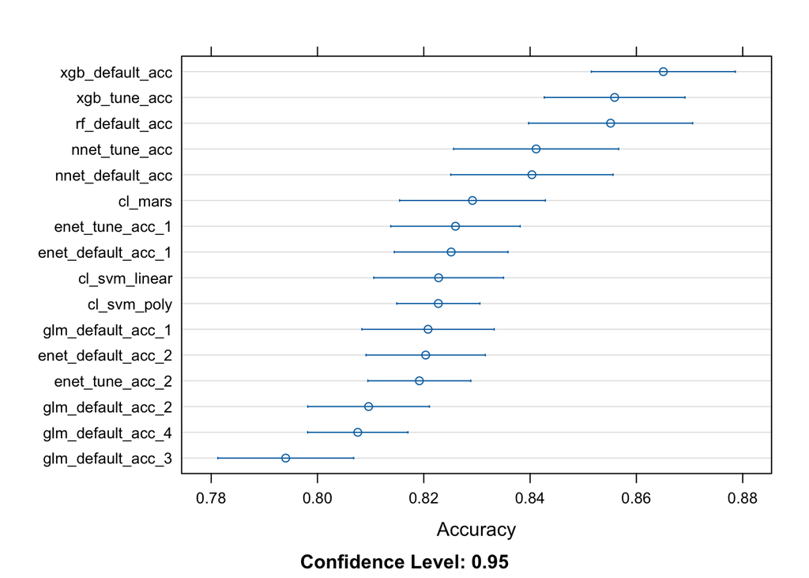

```r
logistic_resamples_acc %>% dotplot(metric = 'Accuracy')
```

`XGB_default` is the best method.

```r
logistic_resamples_roc <- resamples(setNames(logistic_models_roc$models, logistic_models_roc$names))
```

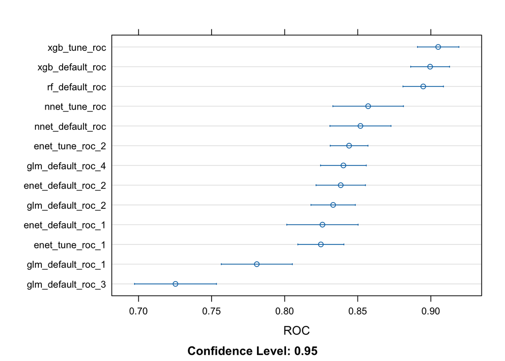

```r
logistic_resamples_roc %>% dotplot(metric = 'ROC')
```

`xgb_tune` is the best model.

Since we know from the visualization that there is imbalance in the number of `events` and `non-events`, we must check the models individually.

```r
xgb_tune_roc <- logistic_models_roc$models[logistic_models_roc$names == 'xgb_tune_roc']
```

```r
confusionMatrix(xgb_tune_roc[[1]])
```

```
## Cross-Validated (5 fold, repeated 3 times) Confusion Matrix
##
## (entries are percentual average cell counts across resamples)
##
##            Reference
## Prediction  event non_event
##   event      14.2       5.1
##   non_event   8.7      72.0
##
##  Accuracy (average) : 0.8623
```

```r
xgb_default_acc <- logistic_models_acc$models[logistic_models_acc$names == 'xgb_default_acc']
```

```r
confusionMatrix(xgb_default_acc[[1]])
```

```
## Cross-Validated (5 fold, repeated 3 times) Confusion Matrix
##
## (entries are percentual average cell counts across resamples)
##
##            Reference
## Prediction  event non_event
##   event      13.4       4.0
##   non_event   9.5      73.1
##
##  Accuracy (average) : 0.8651
```

Since it is harder to predict `event`, I will chose the model with the higher true positive event ratio, i.e. `xgb_tune_roc`.

```r
LM_default_4 <- linear_models$models[linear_models$names == 'LM_default_4']
```

### Variable importance

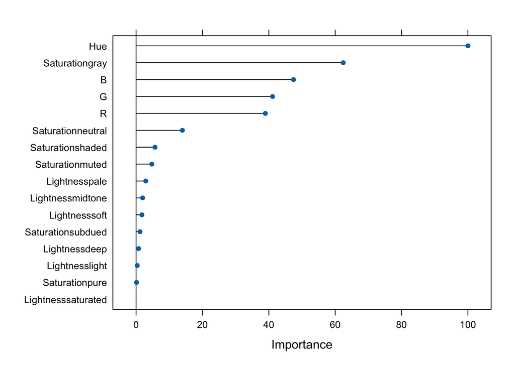

```r
xgb_tune_roc[[1]] %>% varImp() %>% plot()
```

```r
LM_default_4[[1]] %>% varImp()
```

```
## lm variable importance
##
##   only 20 most important variables shown (out of 64)
##
##                        Overall
## G                      100.000
## R                       39.586
## Lightnesspale           35.340
## Lightnesslight          29.049
## Lightnesssoft           23.598
## `Lightnesspale:G`       23.518
## `Lightnesslight:G`      20.984
## Saturationneutral       19.246
## `Lightnesssoft:G`       16.936
## B                       16.915
## Saturationgray          14.065
## Saturationshaded        14.057
## Saturationsubdued       11.394
## Hue                     11.082
## `Lightnesslight:Hue`     9.716
## `Lightnesspale:Hue`      9.600
## `Lightnesssoft:Hue`      9.365
## `Lightnessdeep:G`        9.050
## `Saturationpure:B`       8.405
## `Lightnessmidtone:Hue`   8.368
```

In the case of classification, we see that inputs from both models are important for the model. However, in regression task, we see that RGB model is dominant.

### Difficult combinations

Now I will try to see which combinations of `Lightness` and `Saturation` were the most difficult to predict.

First we check for linear model.

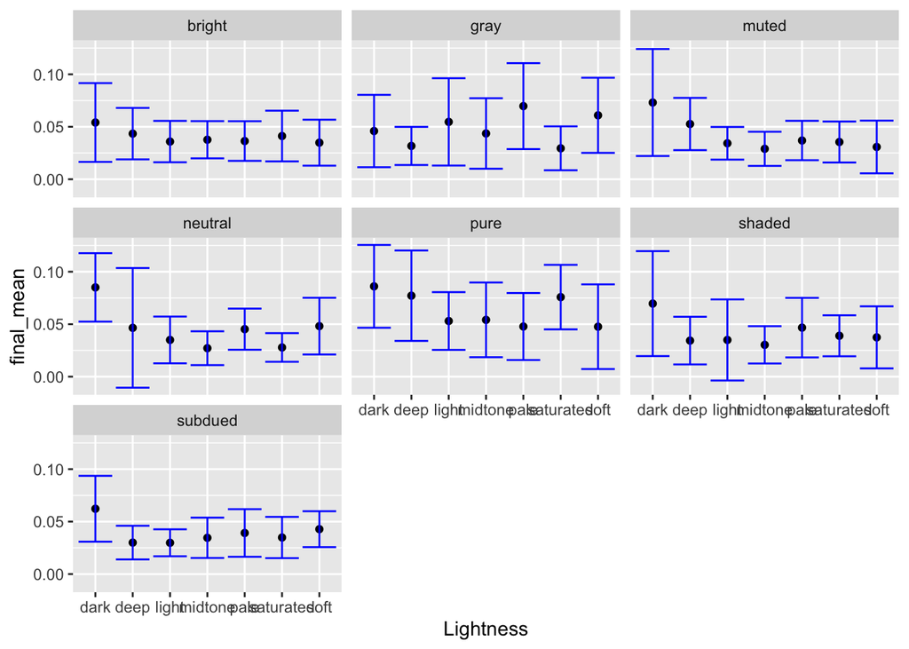

```r
## make sure to filter from best model
LM_default_4[[1]]$pred %>%
  left_join(df_scaled %>%
              select(Lightness, Saturation, y) %>%
              mutate(rowIndex = row_number()),
            by = 'rowIndex') %>%
  mutate(error = abs(y - pred)) %>%
  group_by(Lightness, Saturation, Resample) %>%
  summarize(mean_value = mean(error)) %>%
  group_by(Lightness, Saturation) %>%
  summarize(standard_error = sd(mean_value),
            final_mean = mean(mean_value)) %>%
  ggplot(aes(y = final_mean, x = Lightness)) +
  geom_point() +
  geom_errorbar(aes(ymin = final_mean - standard_error, ymax = final_mean +standard_error), color = 'blue', size = 0.5, height = 0) +
  facet_wrap(~ Saturation)
```

```r
lm_average_preds <- LM_default_4[[1]]$pred %>%
  left_join(df_scaled %>%
              select(Lightness, Saturation, y) %>%
              mutate(rowIndex = row_number()),
            by = 'rowIndex') %>%
  mutate(error = abs(y - pred)) %>%
  group_by(Lightness, Saturation) %>%
  summarize(mean_value = mean(error))
```

To classify the groups, I have considered those which have average error more than 1 standard deviation to be difficult to classify and vice versa.

```r
lm_sd <- (LM_default_4[[1]]$pred %>%
  left_join(df_scaled %>%
              select(Lightness, Saturation, y) %>%
              mutate(rowIndex = row_number()),
            by = 'rowIndex') %>%
  mutate(error = abs(y - pred)))$error %>% sd()
```

```r
lm_average_preds %>%
  filter(mean_value >= lm_sd)
```

```
## # A tibble: 25 × 3
## # Groups:   Lightness [7]
##    Lightness Saturation mean_value
##    <chr>     <chr>           <dbl>
##  1 dark      bright         0.0531
##  2 dark      gray           0.0449
##  3 dark      muted          0.0753
##  4 dark      neutral        0.0788
##  5 dark      pure           0.0825
##  6 dark      shaded         0.0710
##  7 dark      subdued        0.0631
##  8 deep      bright         0.0449
##  9 deep      muted          0.0525
## 10 deep      neutral        0.0445
## # ℹ 15 more rows
```

```r
lm_average_preds %>%
  filter(mean_value < lm_sd) %>%
  arrange(mean_value)
```

```
## # A tibble: 24 × 3
## # Groups:   Lightness [6]
##    Lightness Saturation mean_value
##    <chr>     <chr>           <dbl>
##  1 midtone   neutral        0.0262
##  2 midtone   shaded         0.0287
##  3 saturated gray           0.0291
##  4 saturated neutral        0.0294
##  5 light     subdued        0.0304
##  6 midtone   muted          0.0308
##  7 saturated subdued        0.0314
##  8 deep      gray           0.0316
##  9 deep      subdued        0.0321
## 10 soft      muted          0.0323
## # ℹ 14 more rows
```

Next I will check for the classification models.

```r
cl_average_preds <- xgb_tune_roc[[1]]$pred %>%
  filter(nrounds == xgb_tune_roc[[1]]$bestTune$nrounds) %>%
  filter(max_depth == xgb_tune_roc[[1]]$bestTune$max_depth) %>%
  filter(eta == xgb_tune_roc[[1]]$bestTune$eta) %>%
  left_join(df_scaled %>%
              select(Lightness, Saturation, outcome) %>%
              mutate(rowIndex = row_number()),
            by = 'rowIndex') %>%
  group_by(Lightness, Saturation) %>%
  summarize(mean(pred != obs)) %>% arrange(`mean(pred != obs)`)
##remove all interactions no need
```

```r
cl_avg <- xgb_tune_roc[[1]]$pred %>%
  filter(nrounds == xgb_tune_roc[[1]]$bestTune$nrounds) %>%
  filter(max_depth == xgb_tune_roc[[1]]$bestTune$max_depth) %>%
  filter(eta == xgb_tune_roc[[1]]$bestTune$eta) %>%
  left_join(df_scaled %>%
              select(Lightness, Saturation, outcome) %>%
              mutate(rowIndex = row_number()),
            by = 'rowIndex') %>%
  summarize(mean(pred != obs))
cl_avg[[1]]
```

```
## [1] 0.1377246
```

```r
### the worst ones
cl_average_preds %>%
  filter(`mean(pred != obs)` >= cl_avg[[1]]) %>%
  arrange(desc(`mean(pred != obs)`))
```

```
## # A tibble: 21 × 3
## # Groups:   Lightness [7]
##    Lightness Saturation `mean(pred != obs)`
##    <chr>     <chr>                    <dbl>
##  1 midtone   neutral                  0.412
##  2 dark      gray                     0.333
##  3 saturated gray                     0.306
##  4 light     subdued                  0.278
##  5 pale      shaded                   0.278
##  6 soft      pure                     0.259
##  7 dark      bright                   0.241
##  8 dark      pure                     0.222
##  9 pale      subdued                  0.222
## 10 soft      shaded                   0.222
## # ℹ 11 more rows
```

```r
### the best ones
cl_average_preds %>%
  filter(`mean(pred != obs)` < cl_avg[[1]]) %>%
  arrange((`mean(pred != obs)`))
```

```
## # A tibble: 28 × 3
## # Groups:   Lightness [7]
##    Lightness Saturation `mean(pred != obs)`
##    <chr>     <chr>                    <dbl>
##  1 deep      bright                  0
##  2 light     bright                  0
##  3 light     pure                    0
##  4 pale      muted                   0
##  5 saturated bright                  0
##  6 saturated muted                   0
##  7 midtone   bright                  0.0185
##  8 soft      neutral                 0.0370
##  9 deep      pure                    0.0556
## 10 light     muted                   0.0556
## # ℹ 18 more rows
```

### Interpretations

I will start with regression models.

```r
viz_grid <- expand.grid(
  R = seq(0, 255, length.out = 101),
  G = seq(0, 255, length.out = 101),
  B = 127,
  Hue = 20,
  Saturation = c('bright', 'gray', 'muted', 'neutral', 'pure', 'shaded', 'subdued'),
  Lightness = c('dark', 'deep', 'light', 'midtone', 'pale', 'saturated', 'soft'),
  KEEP.OUT.ATTRS = FALSE,
  stringsAsFactors = FALSE
)
```

```r
lm_pred <- predict(LM_default_4[[1]], newdata = viz_grid)
```

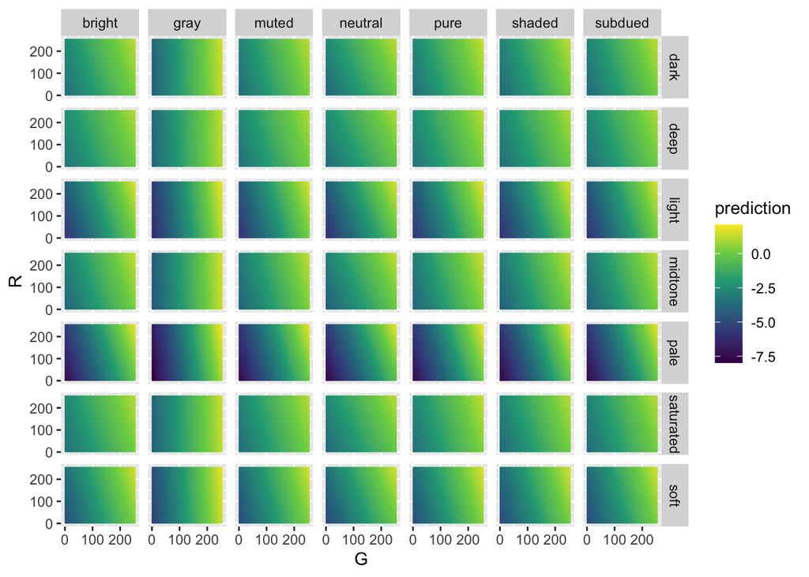

```r
viz_grid %>%
  mutate(prediction = lm_pred) %>%
  ggplot(aes(x = G, y = R)) +
  geom_raster(aes(fill = prediction)) +
  facet_grid(Lightness ~ Saturation) +
  scale_fill_viridis_c()
```

```r
viz_grid_2 <- expand.grid(
  B = seq(0, 255, length.out = 101),
  Hue = seq(0, 40, length.out = 101),
  R = 127,
  G = 127,
  Saturation = c('bright', 'gray', 'muted', 'neutral', 'pure', 'shaded', 'subdued'),
  Lightness = c('dark', 'deep', 'light', 'midtone', 'pale', 'saturated', 'soft'),
  KEEP.OUT.ATTRS = FALSE,
  stringsAsFactors = FALSE
)
```

```r
cl_pred <- predict(xgb_tune_roc[[1]], newdata = viz_grid_2, type = "prob")
```

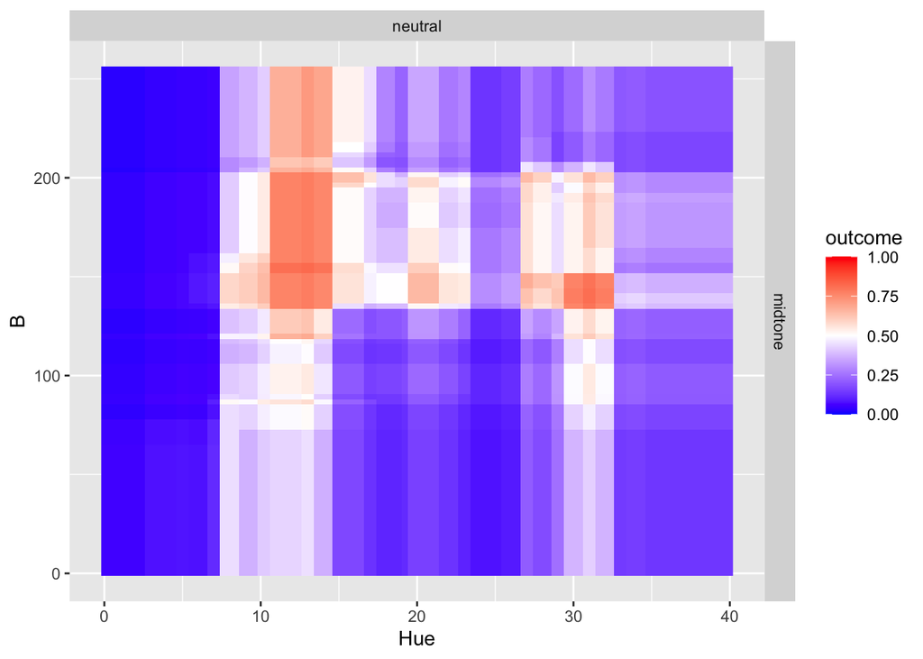

```r
viz_grid_2 %>%
  mutate(outcome = cl_pred$event) %>%
  filter(Lightness == 'midtone', Saturation == 'neutral') %>%
  ggplot(aes(x = Hue, y = B)) +
  geom_raster(aes(fill = outcome)) +
  facet_grid(Lightness ~ Saturation) +
  scale_fill_gradient2(low = 'blue', mid = 'white', high = 'red', midpoint = 0.5,
                       limits = c(0,1))
```

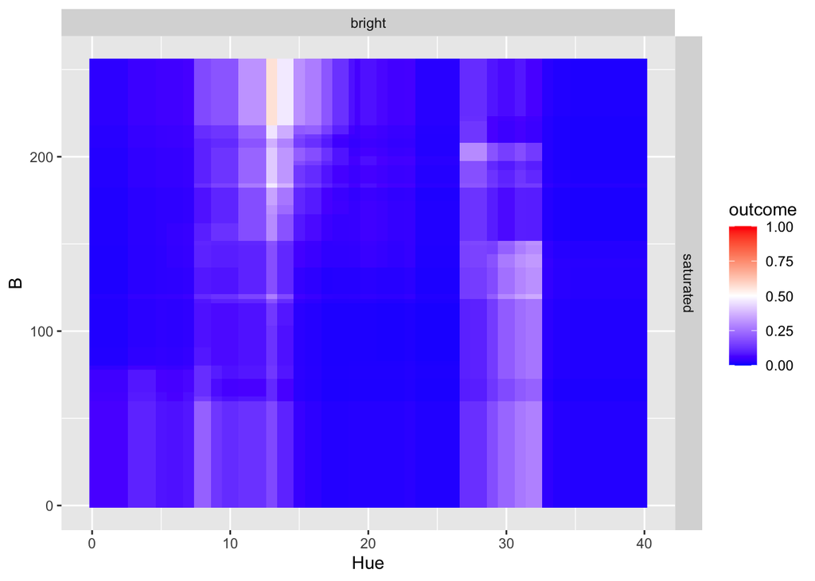

```r
viz_grid_2 %>%
  mutate(outcome = cl_pred$event) %>%
  filter(Lightness == 'saturated', Saturation == 'bright') %>%
  ggplot(aes(x = Hue, y = B)) +
  geom_raster(aes(fill = outcome)) +
  facet_grid(Lightness ~ Saturation)  +
  scale_fill_gradient2(low = 'blue', mid = 'white', high = 'red', midpoint = 0.5,
                       limits = c(0,1))
```

From the surface plots of classification, it is very clear why the combination `neutral:midtone` is difficult to predict because of the presence of many different regions of high and low outcomes. On the other hand, the combination `bright:saturated` shows very similar values throughout which would make it easier to predict.